# Visualization

This document serves as the **main exploratory visualization file** for dataset (daily records from 2013 to 2025). The primary goal is to **discover patterns, trends, anomalies, and potential relationships** in the data through various visualization techniques and statistical summaries.

Different plotting methods, smoothing techniques, comparative overlays (especially highlighting Ramadan periods), rolling statistics, trend analysis, extreme event detection, and hypothesis-driven comparisons are used to uncover possible seasonal behaviors, long-term changes, and month-specific phenomena.

All visualizations and summaries are **exploratory** — they aim to reveal insights rather than test formal hypotheses, although several visualizations are motivated by the research questions.

## Loading the cleaned dataset

The cleaned dataset is loaded from CSV. This file contains daily weather variables including temperature, humidity, wind speed, heat index, VPD, etc.

```r
my_data <- readr::read_csv('D:/climetr/climetr_analysis/datasets/birjand_clean_dataset.csv')
```

## Long-term temperature overview (2013–2025)

This line + smooth plot shows the overall temperature behavior across the entire period, helping to visually identify any long-term warming or seasonal patterns.

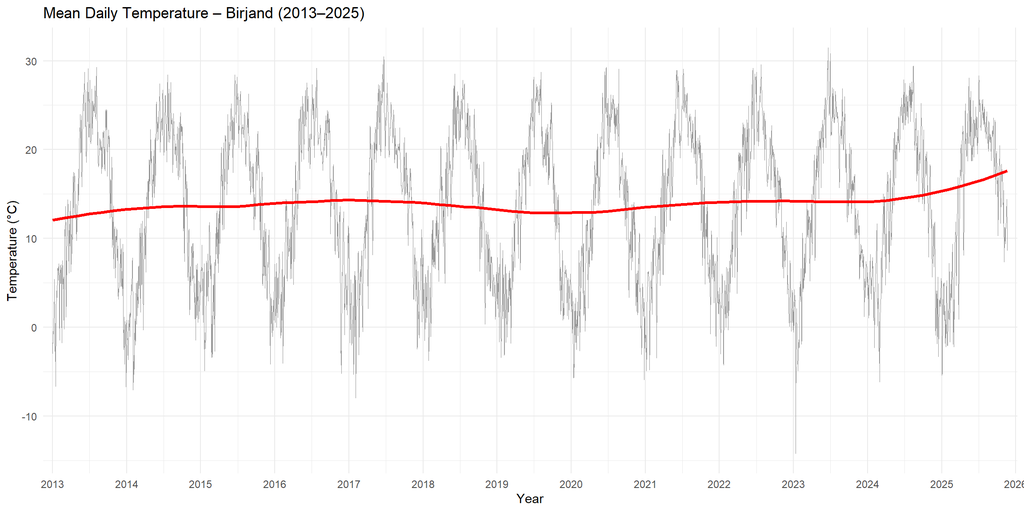

```r
my_data %>%
  ggplot() +
  geom_line(aes(x = full_date, y = temp_air_mean_c),
            linewidth = 0.2, color = "grey60") +
  geom_smooth(aes(x = full_date, y = temp_air_mean_c),
              method = "loess",
              span = 0.4,
              se = FALSE,
              color = "red",
              linewidth = 1.1) +
  scale_x_date(
    date_breaks = "1 year",
    date_labels = "%Y",
    expand = c(0.01, 0.01)
  ) +
  labs(title = "Mean Daily Temperature – Birjand (2013–2025)",
       x = "Year", y = "Temperature (°C)") +
  theme_minimal()
```

## Yearly temperature with Ramadan highlight (selected year)

The figure below shows the daily mean air temperature throughout a selected year (2024). A loess smoothing curve is added to emphasize the seasonal temperature cycle, while days belonging to Ramadan are highlighted in red.

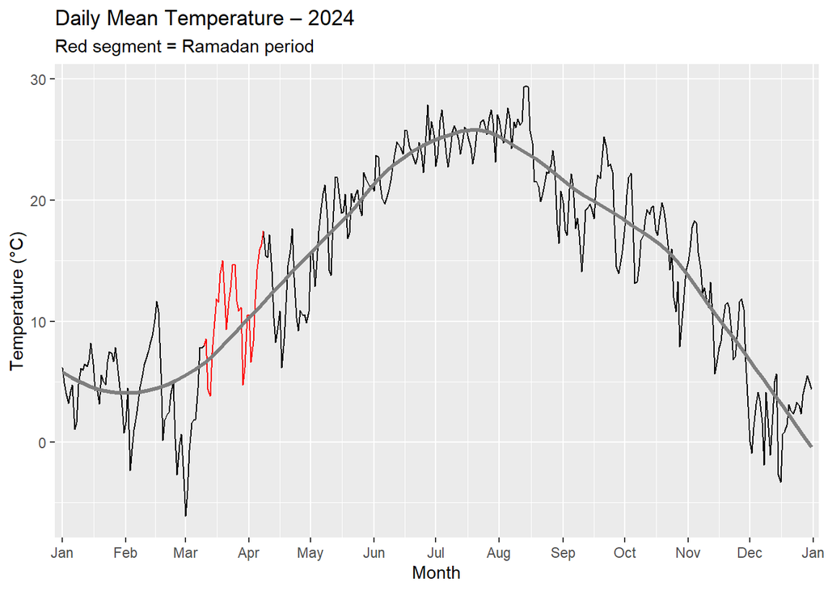

```r
selected_year <- 2024

my_data %>% filter(year == selected_year) %>% ggplot() +
  geom_line(mapping = aes(x=full_date, y=temp_air_mean_c)) +
  geom_line(data = filter(my_data, year == selected_year & is_ramadan == TRUE), mapping = aes(x=full_date, y=temp_air_mean_c), color="red") +
    geom_smooth(aes(x = full_date, y = temp_air_mean_c),
              method = "loess",
              span = 0.4,
              se = FALSE,
              color = "gray50",
              linewidth = 1.1) +
  scale_x_date(
    date_breaks = "1 month",
    date_labels = "%b",
    expand = c(0.01, 0.01)
  ) +
  labs(title = paste("Daily Mean Temperature –", selected_year),
       subtitle = "Red segment = Ramadan period", x = "Month", y = "Temperature (°C)")
```

## Same style comparison for other variables in the selected year

I apply the same visualization approach to humidity, wind speed, dew point temperature, daily temperature range, vapor pressure deficit (VPD), Heat Index, Thermal Discomfort Delta, and rolling temperature averages. Ramadan days are highlighted in red to facilitate visual comparison with the rest of the year.

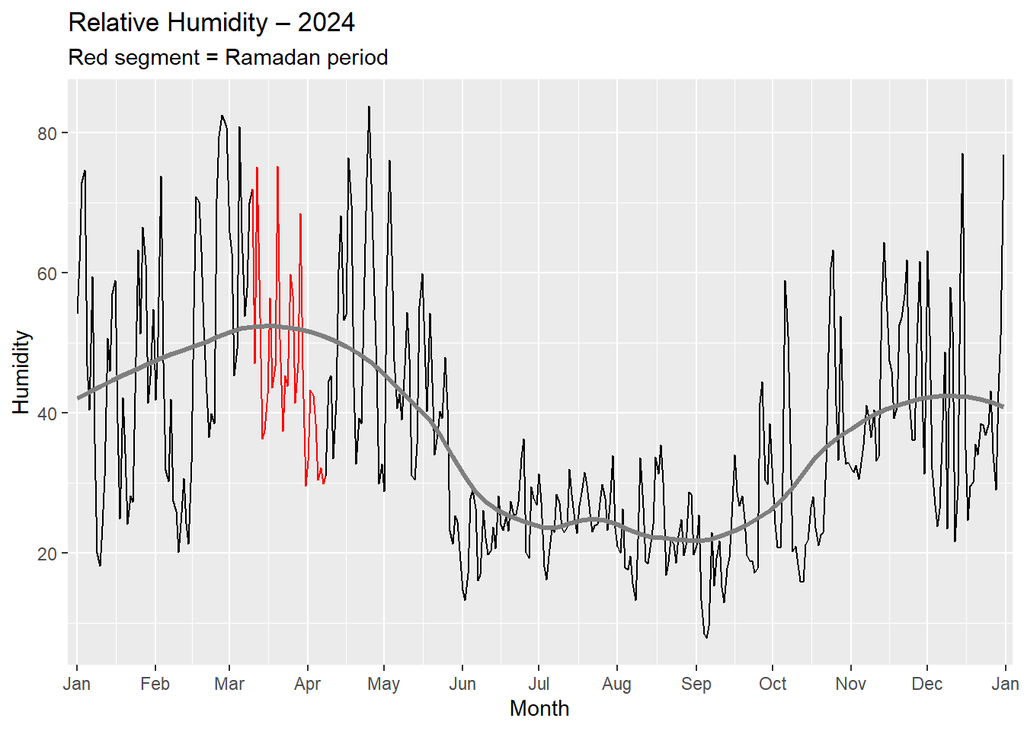

```r
selected_year <- 2024

# Humidity
my_data %>% filter(year == selected_year) %>% ggplot() +
  geom_line(mapping = aes(x=full_date, y=humidity_relative_percent)) +
  geom_line(data = . %>% filter(is_ramadan == TRUE), mapping = aes(x=full_date, y=humidity_relative_percent), color="red") +
  geom_smooth(aes(x = full_date, y = humidity_relative_percent),
          method = "loess",
          span = 0.4,
          se = FALSE,
          color = "gray50",
          linewidth = 1.1) +
  scale_x_date(
    date_breaks = "1 month",
    date_labels = "%b",
    expand = c(0.01, 0.01)
  ) +
  labs(title = paste("Relative Humidity –", selected_year),
       subtitle = "Red segment = Ramadan period", x = "Month", y = "Humidity")
```

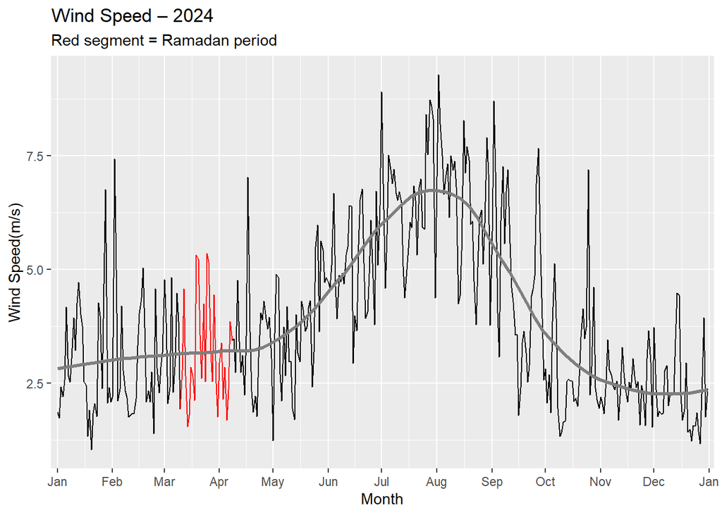

```r
# Wind speed
my_data %>% filter(year == selected_year) %>%
  ggplot() +
  geom_line(aes(x = full_date, y = wind_speed_ms)) +
  geom_line(data = . %>% filter(is_ramadan == TRUE),
            aes(x = full_date, y = wind_speed_ms), color = "red") +
    geom_smooth(aes(x = full_date, y = wind_speed_ms),
          method = "loess",
          span = 0.4,
          se = FALSE,
          color = "gray50",
          linewidth = 1.1) +
  scale_x_date(
    date_breaks = "1 month",
    date_labels = "%b",
    expand = c(0.01, 0.01)
  ) +
  labs(title = paste("Wind Speed –", selected_year), subtitle = "Red segment = Ramadan period", x = "Month", y = "Wind Speed(m/s)")
```

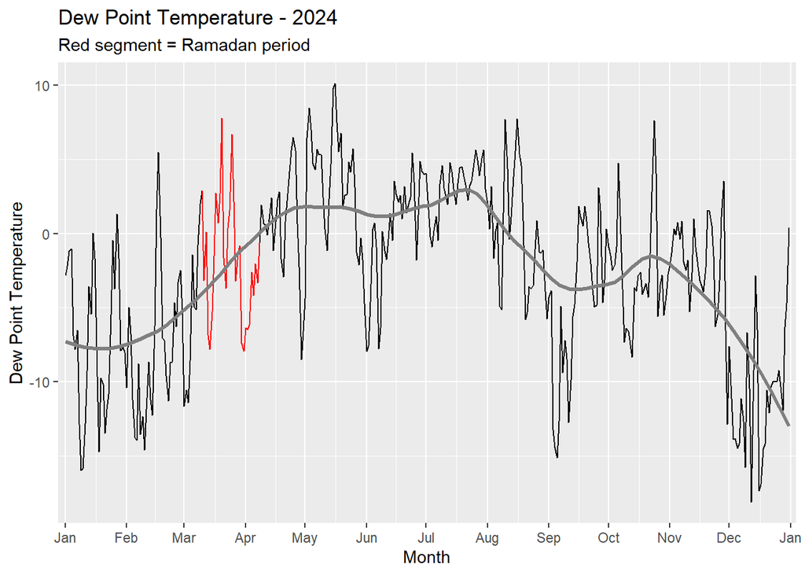

```r
# Dew point
my_data %>% filter(year == selected_year) %>%
  ggplot() +
  geom_line(aes(x = full_date, y = temp_dewpoint_c)) +
  geom_line(data = . %>% filter(is_ramadan == TRUE),
            aes(x = full_date, y = temp_dewpoint_c), color = "red") +
  geom_smooth(aes(x = full_date, y = temp_dewpoint_c),
          method = "loess",
          span = 0.4,
          se = FALSE,
          color = "gray50",
          linewidth = 1.1) +
  scale_x_date(
    date_breaks = "1 month",
    date_labels = "%b",
    expand = c(0.01, 0.01)
  ) +
  labs(title = paste("Dew Point Temperature -", selected_year), subtitle = "Red segment = Ramadan period", x = "Month", y = "Dew Point Temperature")
```

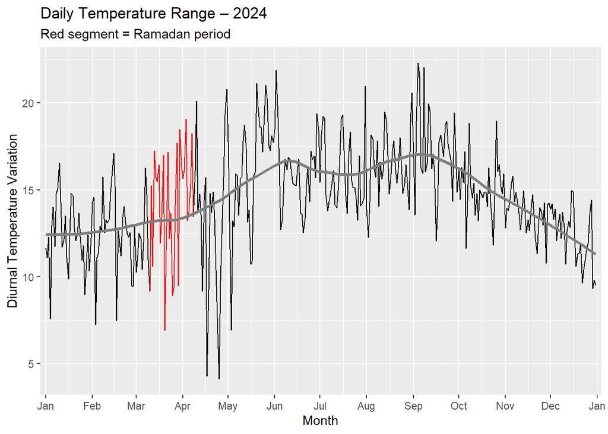

```r
# Daily temperature range
my_data %>% filter(year == selected_year) %>%
  ggplot() +
  geom_line(aes(x = full_date, y = temp_range)) +
  geom_line(data = . %>% filter(is_ramadan == TRUE),
            aes(x = full_date, y = temp_range), color = "red") +
  geom_smooth(aes(x = full_date, y = temp_range),
          method = "loess",
          span = 0.4,
          se = FALSE,
          color = "gray50",
          linewidth = 1.1) +
  scale_x_date(
    date_breaks = "1 month",
    date_labels = "%b",
    expand = c(0.01, 0.01)
  ) +
  labs(title = paste("Daily Temperature Range –", selected_year), subtitle = "Red segment = Ramadan period", x = "Month", y = "Diurnal Temperature Variation")
```

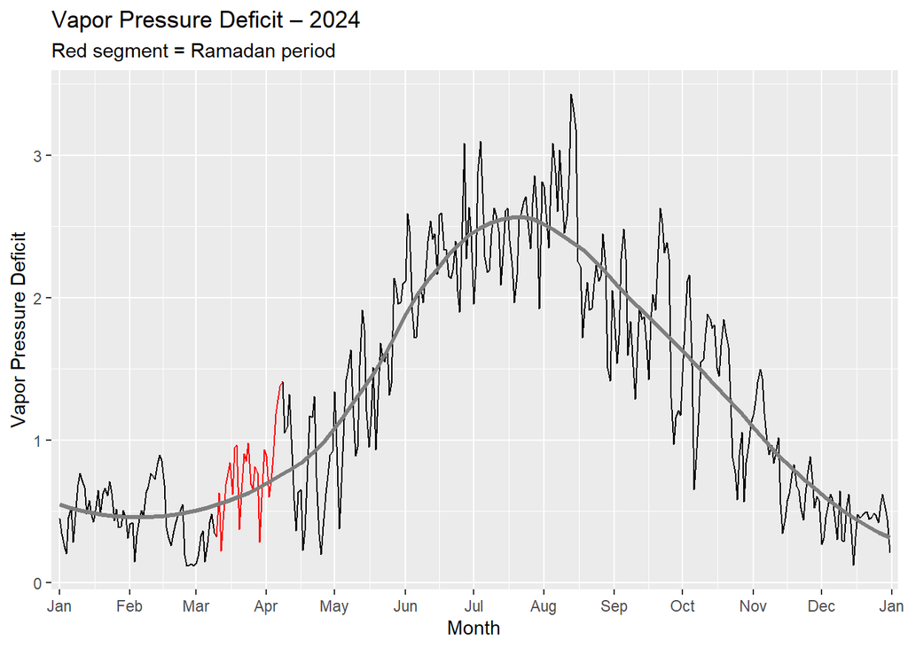

```r
# Vapor Pressure Deficit
my_data %>% filter(year == selected_year) %>%
  ggplot() +
  geom_line(aes(x = full_date, y = vpd_kpa)) +
  geom_line(data = . %>% filter(is_ramadan == TRUE),
            aes(x = full_date, y = vpd_kpa), color = "red") +
  geom_smooth(aes(x = full_date, y = vpd_kpa),
          method = "loess",
          span = 0.4,
          se = FALSE,
          color = "gray50",
          linewidth = 1.1) +
  scale_x_date(
    date_breaks = "1 month",
    date_labels = "%b",
    expand = c(0.01, 0.01)
  ) +
  labs(title = paste("Vapor Pressure Deficit –", selected_year), subtitle = "Red segment = Ramadan period", x = "Month", y = "Vapor Pressure Deficit")
```

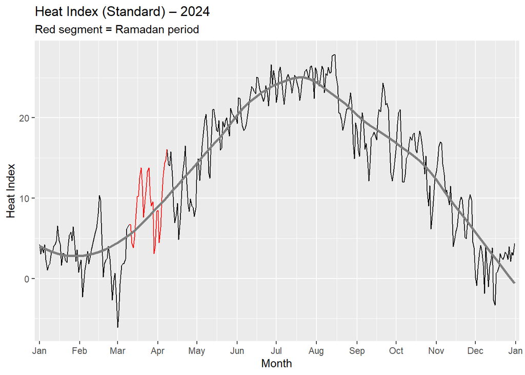

```r
# Standard Heat Index
my_data %>% filter(year == selected_year) %>%
  ggplot() +
  geom_line(aes(x = full_date, y = HI_standard)) +
  geom_line(data = . %>% filter(is_ramadan == TRUE),
            aes(x = full_date, y = HI_standard), color = "red") +
  geom_smooth(aes(x = full_date, y = HI_standard),
          method = "loess",
          span = 0.4,
          se = FALSE,
          color = "gray50",
          linewidth = 1.1) +
  scale_x_date(
    date_breaks = "1 month",
    date_labels = "%b",
    expand = c(0.01, 0.01)
  ) +
  labs(title = paste("Heat Index (Standard) –", selected_year), subtitle = "Red segment = Ramadan period", x = "Month", y = "Heat Index")
```

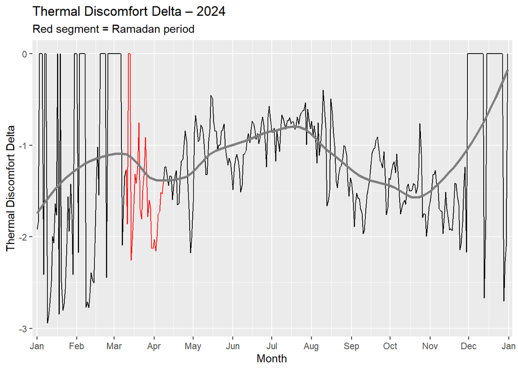

```r
# Thermal Discomfort Delta
my_data %>% filter(year == selected_year) %>%
  ggplot() +
  geom_line(aes(x = full_date, y = heat_index_rel_temp)) +
  geom_line(data = . %>% filter(is_ramadan == TRUE),
            aes(x = full_date, y = heat_index_rel_temp), color = "red") +
  geom_smooth(aes(x = full_date, y = heat_index_rel_temp),
          method = "loess",
          span = 0.4,
          se = FALSE,
          color = "gray50",
          linewidth = 1.1) +
  scale_x_date(
    date_breaks = "1 month",
    date_labels = "%b",
    expand = c(0.01, 0.01)
  ) +
  labs(title = paste("Thermal Discomfort Delta –", selected_year), subtitle = "Red segment = Ramadan period", x = "Month", y = "Thermal Discomfort Delta")
```

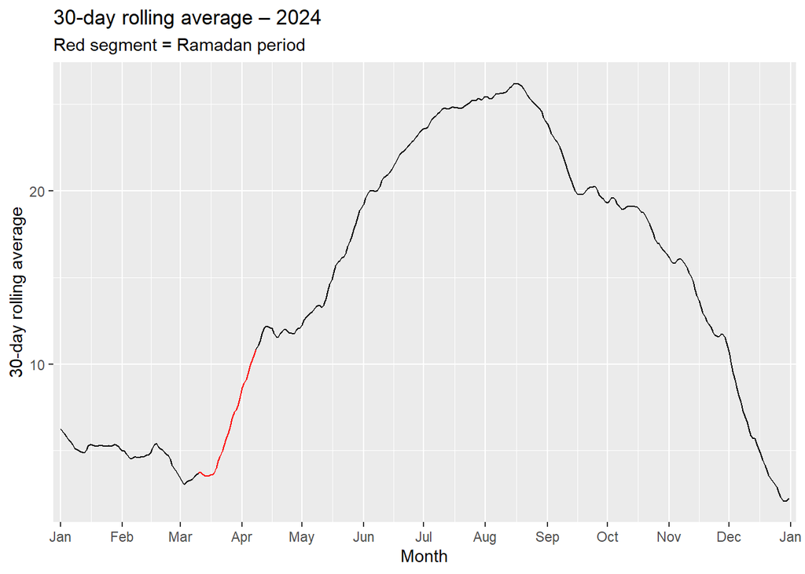

```r
# 30-day rolling average
my_data %>% filter(year == selected_year) %>%
  ggplot() +
  geom_line(aes(x = full_date, y = rolling_avg_30)) +
  geom_line(data = . %>% filter(is_ramadan == TRUE),
            aes(x = full_date, y = rolling_avg_30), color = "red") +
  scale_x_date(
    date_breaks = "1 month",
    date_labels = "%b",
    expand = c(0.01, 0.01)
  ) +
  labs(title = paste("30-day rolling average –", selected_year), subtitle = "Red segment = Ramadan period", x = "Month", y = "30-day rolling average")
```

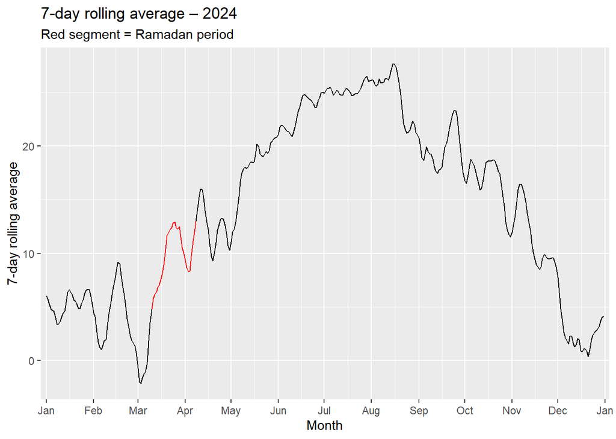

```r
# 7-day rolling average
my_data %>% filter(year == selected_year) %>%
  ggplot() +
  geom_line(aes(x = full_date, y = rolling_avg_7)) +
  geom_line(data = . %>% filter(is_ramadan == TRUE),
            aes(x = full_date, y = rolling_avg_7), color = "red") +
  scale_x_date(
    date_breaks = "1 month",
    date_labels = "%b",
    expand = c(0.01, 0.01)
  ) +
  labs(title = paste("7-day rolling average –", selected_year), subtitle = "Red segment = Ramadan period", x = "Month", y = "7-day rolling average")
```

## Recent temperatures comparations from (2021–2025)

This plot overlays loess-smoothed daily mean temperature curves for the last five years (2021–2025), allowing direct visual comparison of seasonal patterns and interannual variability.

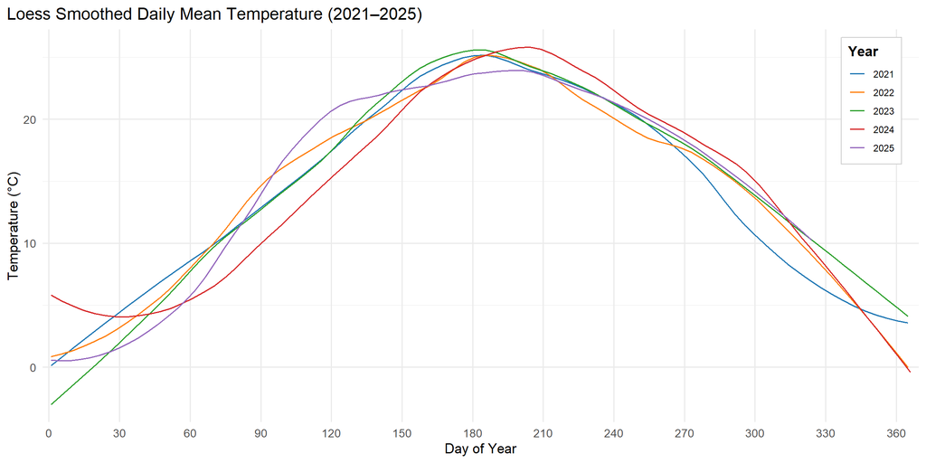

```r
my_colors <- c(
  "2021" = "#1f77b4",
  "2022" = "#ff7f0e",
  "2023" = "#2ca02c",
  "2024" = "#d62728",
  "2025" = "#9467bd"
)

start_year <- 2021
end_year   <- 2025

p <- ggplot() +

  lapply(start_year:end_year, function(yr) {
    geom_smooth(
      data = filter(my_data, year == yr),
      aes(x    = day_of_year,
          y    = temp_air_mean_c,
          color = factor(yr, levels = start_year:end_year)),   # ← مهم
      method   = "loess",
      span     = 0.4,
      se       = FALSE,
      linewidth = 0.6,
      show.legend = TRUE
    )
  }) +

  scale_color_manual(
    values = my_colors,
    name   = "Year",
    labels = as.character(start_year:end_year)
  ) +

  scale_x_continuous(
    breaks = seq(0, 366, by = 30),
    limits = c(1, 366),
    expand = expansion(mult = c(0.01, 0.01))
  ) +

  labs(
    title    = paste0("Loess Smoothed Daily Mean Temperature (", start_year, "–", end_year, ")"),
    x        = "Day of Year",
    y        = "Temperature (°C)",
    color    = "Year"
  ) +

  theme_minimal(base_size = 13) +
  theme(
    legend.position       = c(0.98, 0.98),
    legend.justification  = c("right", "top"),
    legend.background     = element_rect(fill = "white", color = "gray80", linewidth = 0.4),
    legend.title          = element_text(face = "bold"),
    legend.text           = element_text(size = 9),
    panel.grid.minor.x    = element_blank(),
    plot.title.position   = "plot"
  )

print(p)
```

## Comparing end-of-Ramadan rolling average to previous years

For each Ramadan year, I identify the last day of Ramadan and extract its 30-day rolling average temperature. I then compare that value with temperatures observed on the same day-of-year in previous years. This provides a climatological reference for determining whether the end of Ramadan occurred under relatively warm or cool conditions. The end-of-Ramadan observation for the selected year is marked with a red “X”.

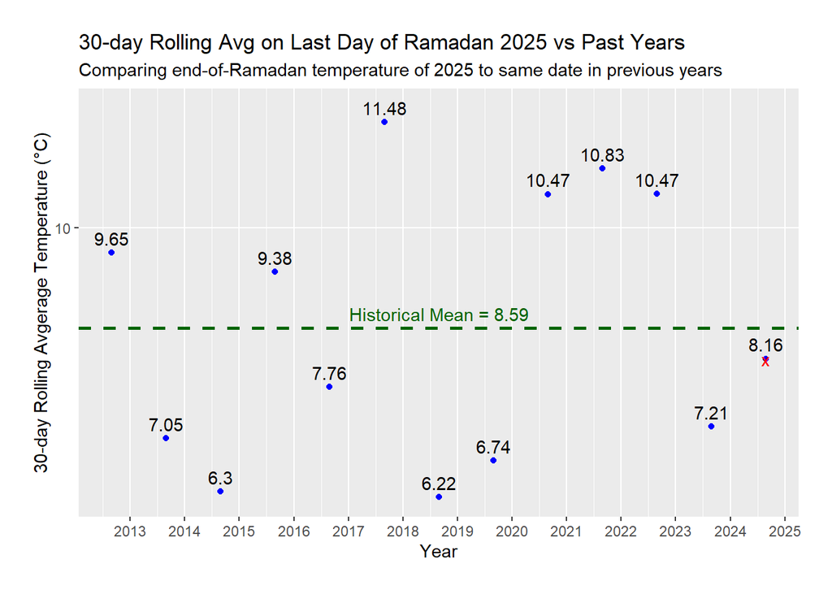

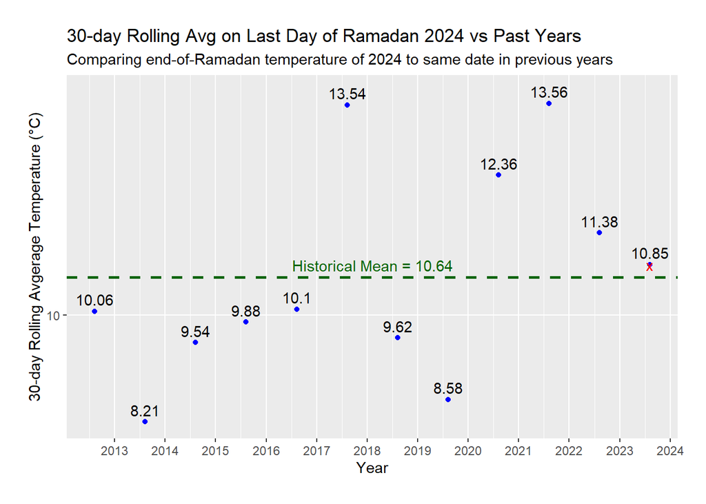

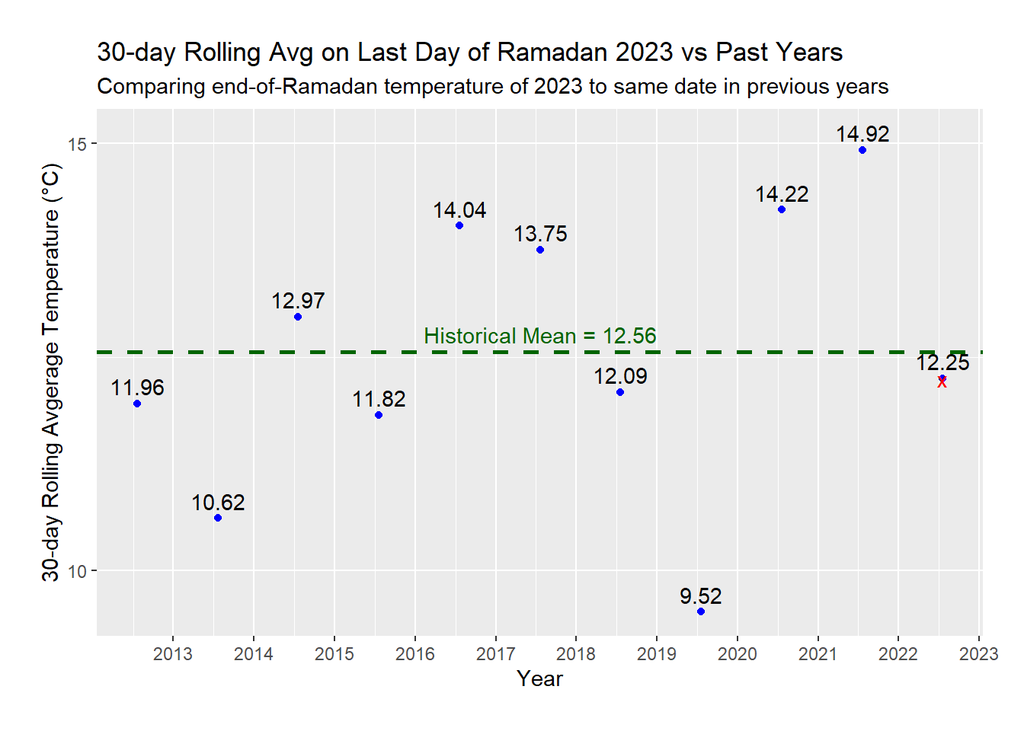

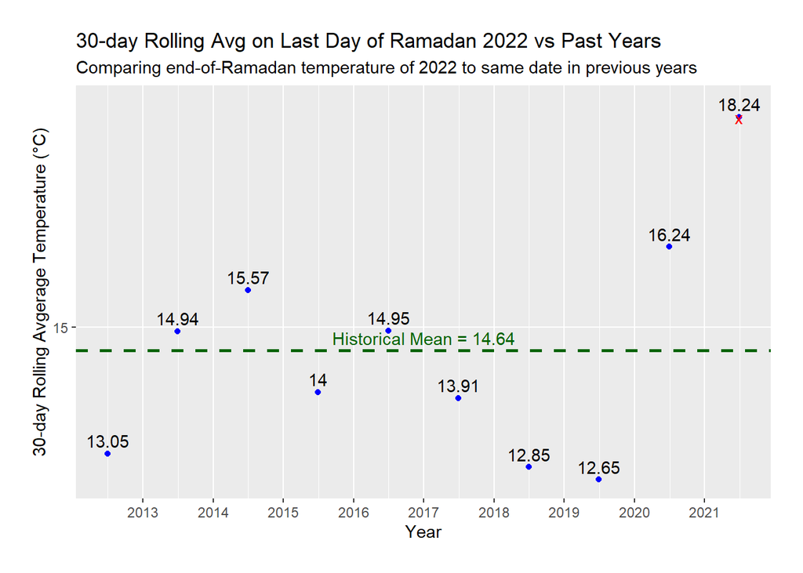

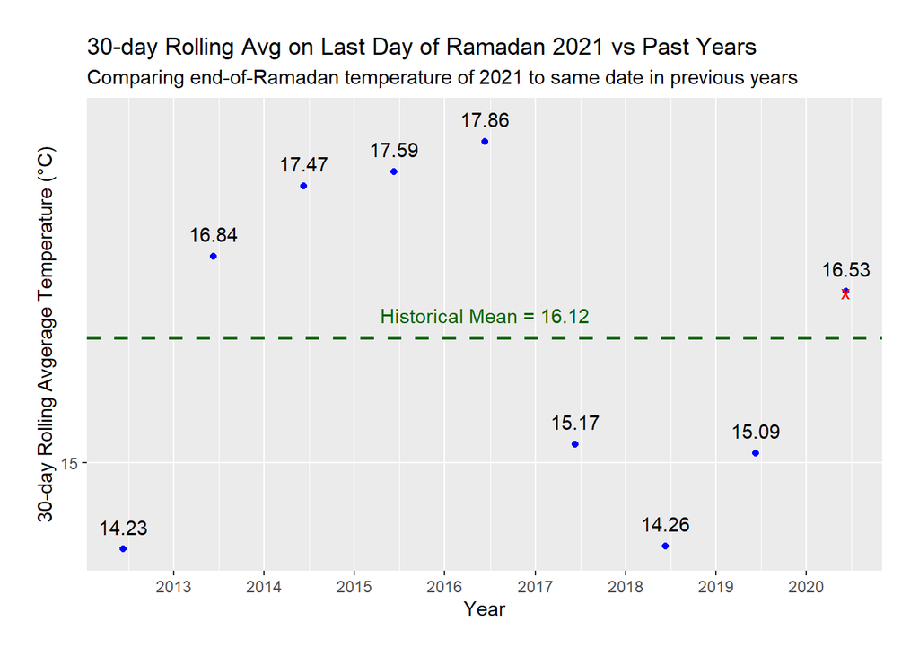

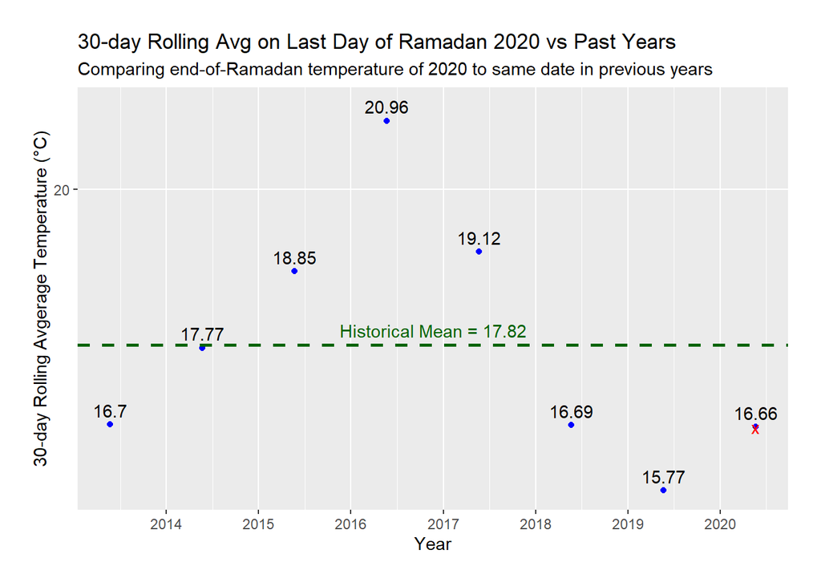

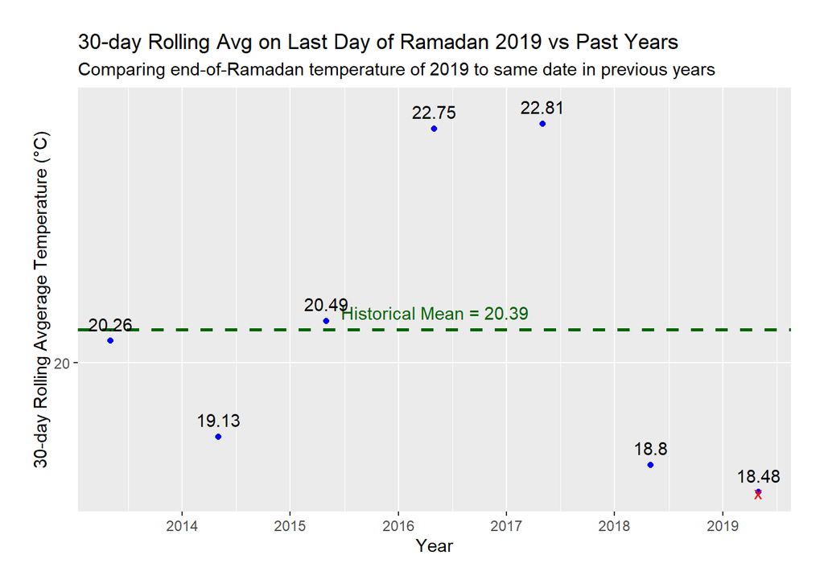

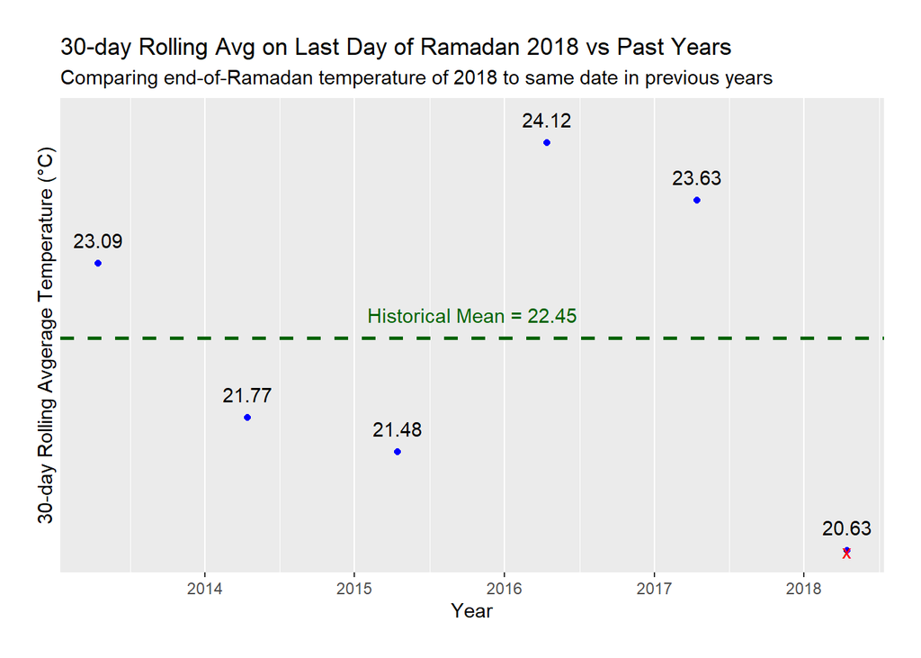

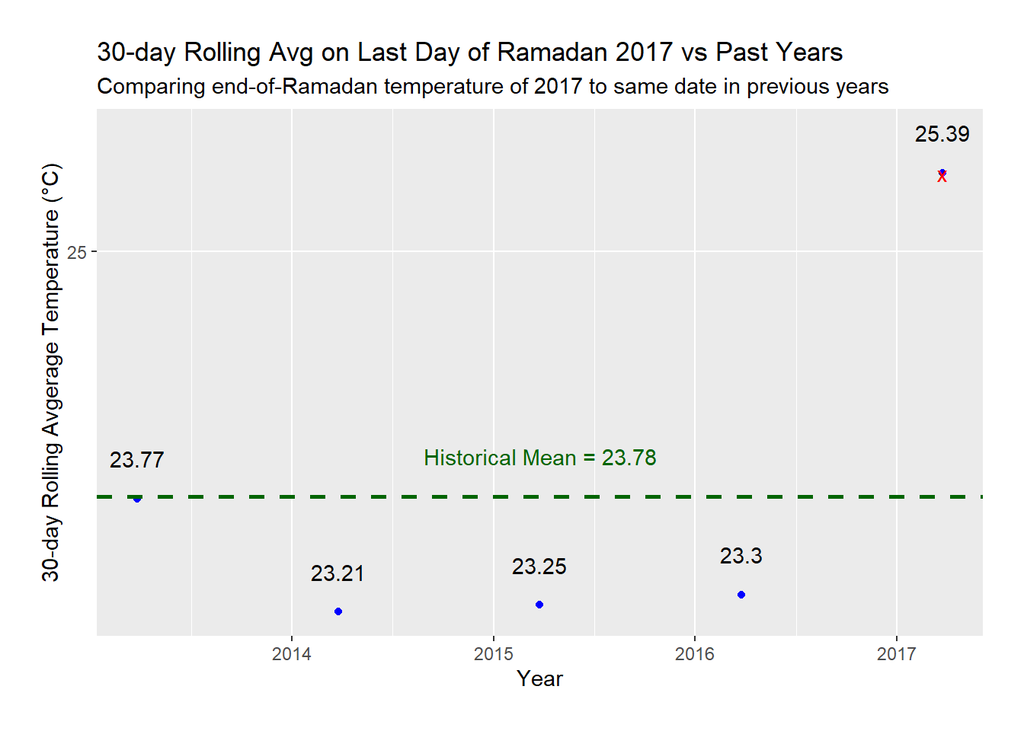

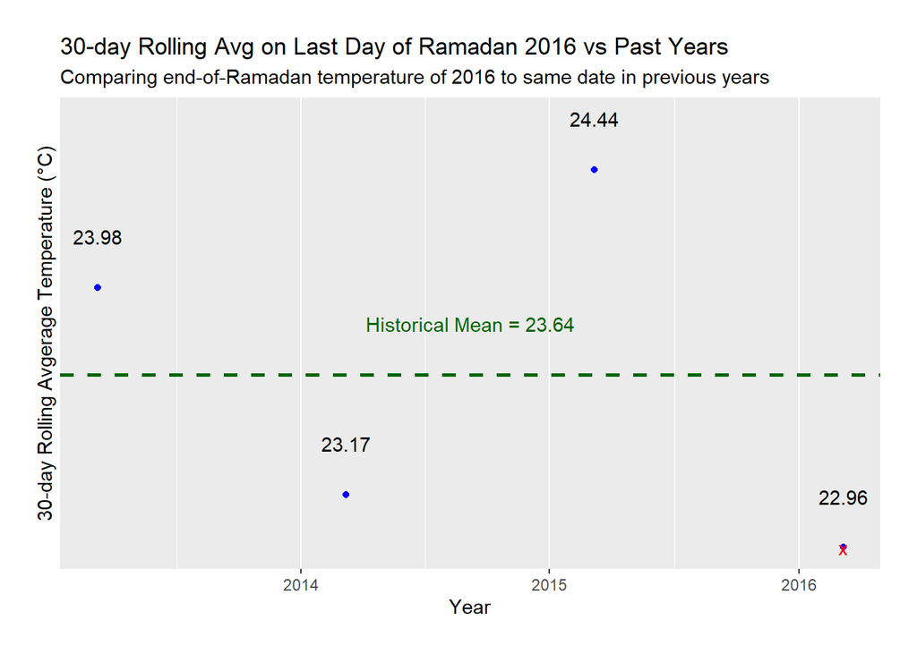

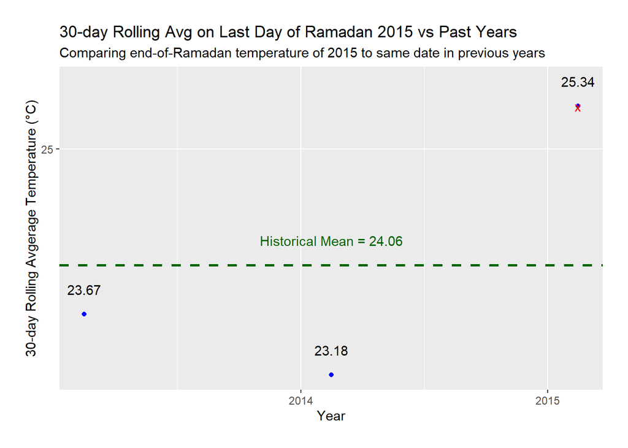

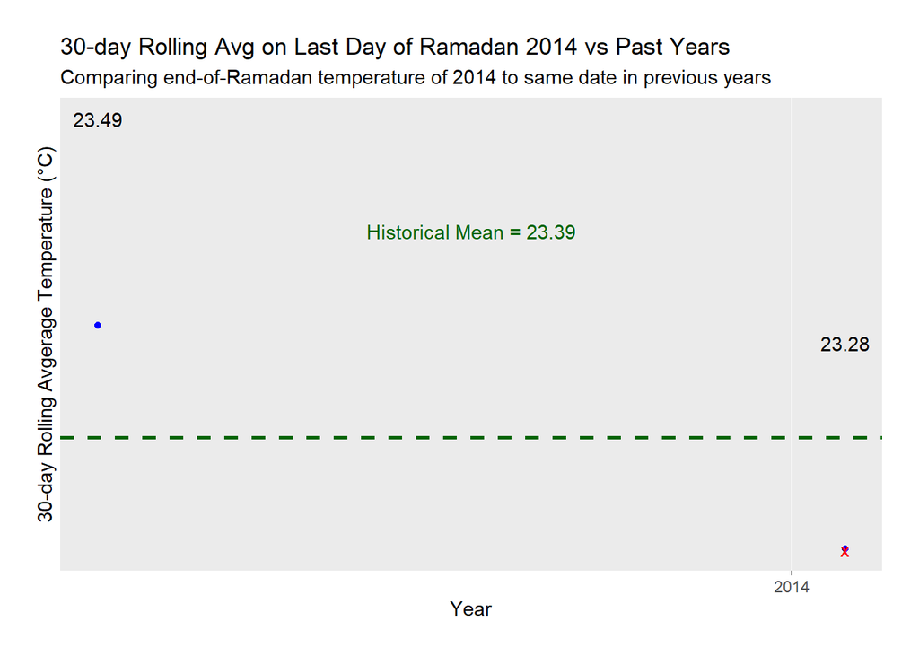

```r
top_padding <- 0.2
start_date <- 2013
end_date <- 2025
plots <- c()

for (ith_year in end_date:(start_date + 1)) {
  ramadan_data <- my_data %>%
    filter(year == ith_year & is_ramadan == TRUE) %>%
    select(day_of_year, full_date, rolling_avg_30)

  last_day_index <- which.max(ramadan_data$day_of_year)
  last_day_doy <- ramadan_data$day_of_year[last_day_index]
  last_day_date <- ramadan_data$full_date[last_day_index]
  ramadan_temperature <- ramadan_data$rolling_avg_30[last_day_index]

  data <- my_data %>%
    filter(day_of_year == last_day_doy & year >= start_date & year <= ith_year) %>%
    select(day_of_year, full_date, year, rolling_avg_30)

  the_plot <- data %>%
    ggplot() +
    geom_point(aes(x = full_date, y = rolling_avg_30), color = "blue") +
    labs(title = paste0("30-day Rolling Avg on Last Day of Ramadan ", ith_year, " vs Past Years"),
         subtitle = paste0("Comparing end-of-Ramadan temperature of ", ith_year, " to same date in previous years"), x = "Year", y = "30-day Rolling Avgerage Temperature (°C)",) +
    annotate("text", x = last_day_date, y = ramadan_temperature,
             label = "x", color = "red") +
    scale_x_date(date_breaks = "12 month", date_labels = "%Y") +
    scale_y_continuous(breaks = seq(-40, 40, 5)) +
    geom_hline(yintercept = mean(data$rolling_avg_30), linetype = "dashed", color = "darkgreen", linewidth = 1) +
    annotate("text", x = mean(data$full_date), y = mean(data$rolling_avg_30) + top_padding,
             label = paste0("Historical Mean = ", round(mean(data$rolling_avg_30), 2)), color = "darkgreen") +
    theme(plot.margin = margin(20, 20, 20, 20))

  # Add value labels for each point
  for (idx in 1:nrow(data)) {
    the_plot <- the_plot +
      annotate("text", x = data[[idx, "full_date"]],
               y = data[[idx, "rolling_avg_30"]] + top_padding,
               label = round(data[[idx, "rolling_avg_30"]], 2), angle = 0)
  }

  plots <- c(plots, the_plot)
}

plots
```

## Monthly mean Heat Index trends across years

This section calculates monthly mean Heat Index values and visualizes their evolution across years. Linear trend lines are added to help identify potential long-term increases or decreases in thermal stress conditions for each month. Numeric labels are colored relative to the long-term monthly average. Red labels indicate years with mean Heat Index values above the monthly average, whereas blue labels indicate values below the monthly average.